# 0_Selection&Exploration

Sergio Andreu-Sanchez

9/9/2022

# CMV Omics - Script 0: Decide which peptides belong to CMV. Check proteins.

```r
library(tidyverse)
library(readxl)
library(pheatmap)
library(vegan)
library(cluster)
library(kmer)
library(ape)
library(MetBrewer)
```

Reading data

```r
Location_dir = '~/Documents/GitHub/CMV_Associations/'


read_excel("~/Resilio Sync/Antibodies_WIS (1)/Results/Supplemenatry_Tables/SupplementaryTable1.xlsx", sheet=2) -> Peptides_Annotation


immuno_matrix_total <- readRDS(paste0(Location_dir, 'Data/Immuno_matrix_postSelection.rds')) %>% filter(grepl("32_|33_", ID ) )


#Selection of Peptides that represent CMV proteins
cmv_peptides <- read_tsv(paste0(Location_dir,"Results/CMV_peptides.tsv"))
cmv_peptides = cmv_peptides$Peptide
cmv_peptides = cmv_peptides[! cmv_peptides == "agilent_7061"] #wrong one
immuno_matrix_total %>% dplyr::select(c("ID", cmv_peptides)) -> cmv_data #There are no NAs
```

Check similarity in presence/absence profiles

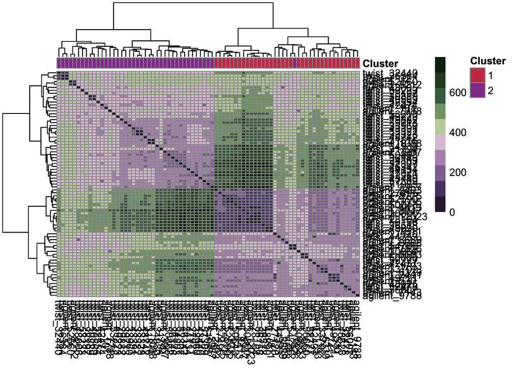

```r
cmv_data  %>% dplyr::select(-c(ID)) %>% t() %>% vegdist(., method = "manhattan") %>% as.matrix() %>%
  `colnames<-`( colnames(cmv_data)[2:dim(cmv_data)[2]] ) -> Distance_matrix
Distance_matrix %>% pam(. , k=2) -> C
Clusters= C$clustering
Clusters %>% as.data.frame() -> Clusters2
Clusters2 %>% mutate(Cluster = as.factor(`.`)) %>% dplyr::select(-`.`) -> Clusters2
rownames(Clusters2) = names(Clusters)

#Cluster colors
met.brewer(name="Klimt", n=2, type="discrete" ) -> A
ann_colors = list( Cluster = c(`1` = A[1], `2`=A[2] ) )
#Heatmap
pheatmap(mat = Distance_matrix, annotation_col = Clusters2, color = met.brewer(name="Cassatt2", type="continuous"), annotation_colors = ann_colors ) %>% print()
```

Check similarity of the sequences using Kmers

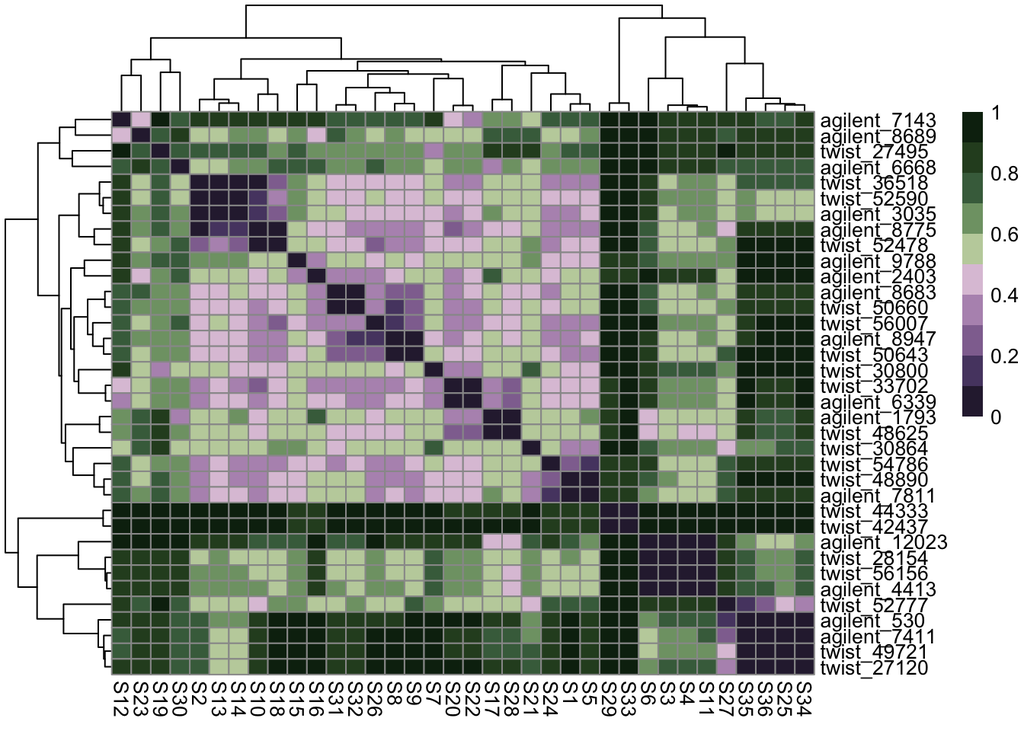

```r
Get_kmer_distance = function(DF, KMER=5){
  DF$aa_seq = str_replace(string = DF$aa_seq, pattern = " \\(./.\\)", replacement = "")
  DF$aa_seq %>% as.list() %>% as.AAbin() %>% kdistance(., k = KMER) %>% as.matrix()  -> D
  rownames(D) = DF$Peptide
  D %>% pheatmap(color = met.brewer(name="Cassatt2", type="continuous"))
}

Peptides_Annotation %>% filter(Peptide %in% rownames(filter(Clusters2, Cluster==1) )) %>% dplyr::select(Peptide, aa_seq)  -> C1
Get_kmer_distance(C1)
```

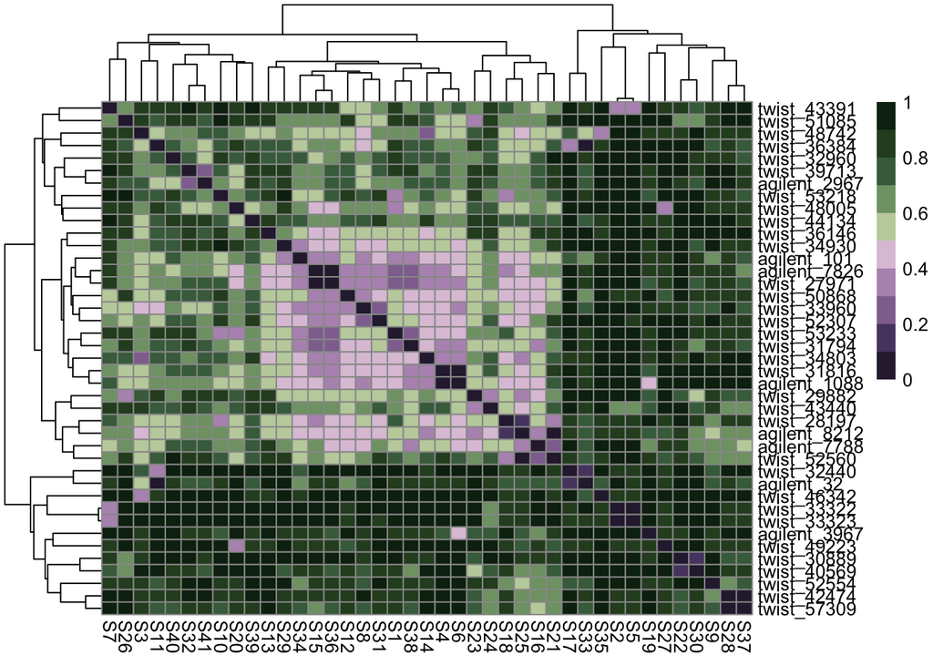

```r
Peptides_Annotation %>% filter(Peptide %in% rownames(filter(Clusters2, Cluster==2) )) %>% dplyr::select(Peptide, aa_seq) -> C2
Get_kmer_distance(C2)
```

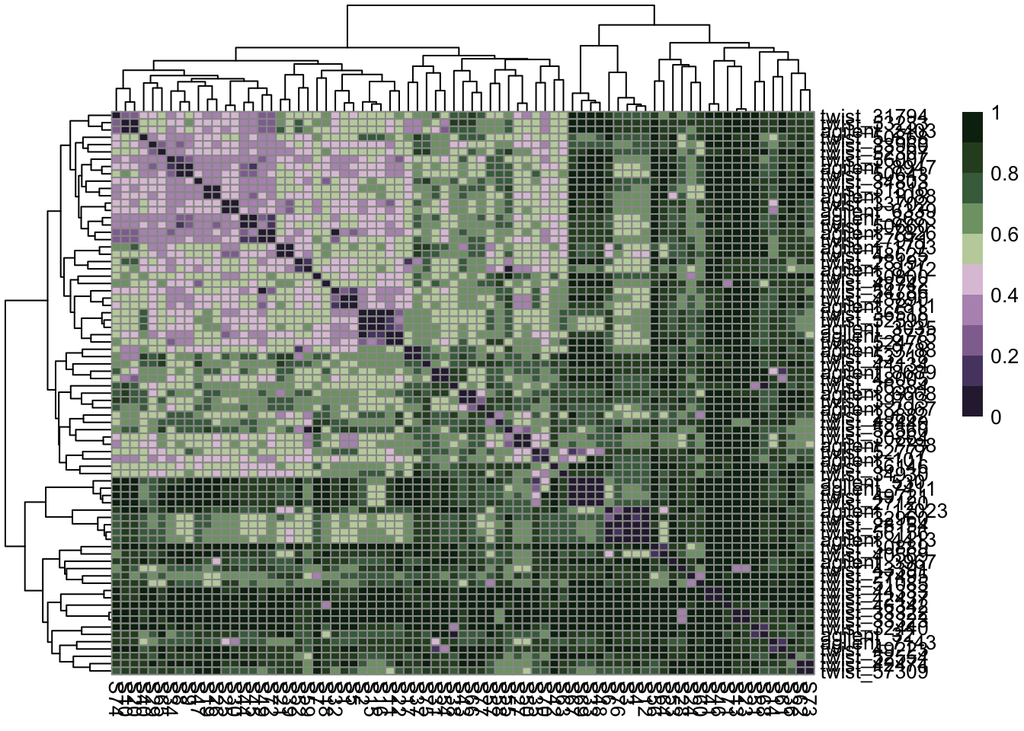

```r
Peptides_Annotation %>% filter(Peptide %in% colnames(cmv_data)) %>% dplyr::select(Peptide, aa_seq) -> C0
Get_kmer_distance(C0)
```

As we see, there are no many redundant peptides. But it might be due to the fact that they are different chuncks of the same protein. Let’s see the annotation of the clusters

```r
Peptides_Annotation %>% filter(Peptide %in% colnames(cmv_data)) %>% select(Peptide, aa_seq, full.name) %>% left_join(., Clusters2 %>% rownames_to_column("Peptide") ) -> Info_Clusters

Same = c("positive (from uniprot): Human herpesvirus 5  Envelope glycoprotein M", "positive (exact): Human herpesvirus 5  Envelope glycoprotein M")
Info_Clusters %>% mutate(`full.name` = ifelse(`full.name` %in% Same,"Glycoprotein M", `full.name` ) ) %>% group_by(Cluster, `full.name`) %>% summarise(N = n())  %>% arrange(desc(N)) %>% print(n=22)
```

```
## # A tibble: 18 × 3
## # Groups:   Cluster [2]
##    Cluster full.name                                                           N
##    <fct>   <chr>                                                           <int>
##  1 1       phosphoprotein 150 & Large structural phosphoprotein               23
##  2 2       phosphoprotein 150 & Large structural phosphoprotein               12
##  3 1       Glycoprotein B precursor & glycoprotein B (1/2)                     5
##  4 1       Glycoprotein M                                                      4
##  5 2       DNA polymerase processivity factor                                  4
##  6 2       Glycoprotein B precursor & glycoprotein B (1/2)                     4
##  7 2       45 kDa immediate-early protein 2                                    3
##  8 2       HCMVUL99 & Tegument protein UL11 homolog                            3
##  9 2       tegument protein pp65 & 65 kDa lower matrix phosphoprotein & p…     3
## 10 1       HCMVUL99 & Tegument protein UL11 homolog                            2
## 11 1       HCMVUS27                                                            2
## 12 2       55 kDa immediate-early protein 1                                    2
## 13 2       HCMVTRL10 = IRL10                                                   2
## 14 2       HCMVUL132                                                           2
## 15 2       HCMVUL80                                                            2
## 16 2       Tegument protein UL25                                               2
## 17 2       Glycoprotein M                                                      1
## 18 2       Uncharacterized protein UL48A                                       1
```

```r
Peptides_Annotation %>% filter(Peptide %in% colnames(cmv_data)) %>% select(Peptide, aa_seq, full.name) -> Peptide_seq

List_proteins = list()
n = 1
for (Protein in unique(Peptide_seq$full.name )){
  Peptide_seq %>% filter(`full.name` == Protein) %>% dplyr::select(-`full.name`) -> Protein_seqs
  S = sapply(Protein_seqs$aa_seq, function(x){ str_split(x, " \\(")[[1]][1] })
  Add = paste0( paste0(">",Protein_seqs$Peptide),"\n", S, sep="\n")

  List_proteins = append(List_proteins, list(Add) )
  names(List_proteins)[[n]] = Protein
  n = n + 1
}
sink(paste0(Location_dir,"/Results/Sequences.fa"))
print(List_proteins)
```

```
## $`phosphoprotein 150 & Large structural phosphoprotein`
##  [1] ">twist_48890\nQTPEQSTPSRIRKAKLSSPMTTTSTSQKPVLGKRVATPHASARAQTVTSTPVQG\n"
##  [2] ">twist_36518\nIAAVGSPVKSTTGMKTVAFDLSSPQKSGTGPQPGSAGMGGAKTPSDAVQNILQK\n"
##  [3] ">agilent_7811\nQTPEQSTPSRIRKAKLSSPMTTTSTSQKPVLGKRVATPHASARAQTVTSTPVQGRLEKQVSGTP\n"
##  [4] ">agilent_8947\nSPAKSAPPSPVKGRGSRVGVPSLKPTLGGKAVVGRPPSVPVSGSAPGRLSGSSRAASTTPTYPA\n"
##  [5] ">twist_50643\nSAPPSPVKGRGSRVGVPSLKPTLGGKAVVGRPPSVPVSGSAPGRLSGSSRAAST\n"
##  [6] ">twist_53233\nTFGAGVNVPAGAGAAILTPTPVNPSTAPAPAPTPTFAGTQTPVNGNSPWAPTAP\n"
##  [7] ">agilent_8775\nSILKPGASAALQSRRSTGIAAVGSPVKSTTGMKTVAFDLSSPQKSGTGPQPGSAGMGGAKTPSD\n"
##  [8] ">agilent_7143\nPQQQQRHAAFSLVSPQVTKASPGRVRRDSAWDVRPLTETRGDLFSGDEDSDSSDGYPPNRQDPR\n"
##  [9] ">twist_52590\nSTTGMKTVAFDLSSPQKSGTGPQPGSAGMGGAKTPSDAVQNILQKIEKIKNTEE\n"
## [10] ">agilent_3035\nGIAAVGSPVKSTTGMKTVAFDLSSPQKSGTGPQPGSAGMGGAKTPSDAVQNILQKIEKIKNTEE\n"
## [11] ">agilent_9788\nTQTPVNGNSPWAPTAPLPGDMNPANWPRERAWALKNPHLAYNPFRMPTTSTASQNTVSTTPRRP\n"
## [12] ">agilent_2403\nFEQPTLTFGAGVNVPAGAGAAILTPTPVNPSTAPAPAPTPTFAGTQTPVNGNSPWAPTAPLPGD\n"
## [13] ">agilent_1793\nEERQQNLQQRQQQPPPPTRKPGASRRLFGSSADEDDDDDDDDEKNIFTPIKKPGTSGKGAASGG\n"
## [14] ">twist_52478\nSTAKSSVSNAPPVASPSILKPGASAALQSRRSTGIAAVGSPVKSTTGMKTVAFD\n"
```

[output cut: 93 more lines]

```r
sink()
#After blasting to reference (GCF_000845245.1) I observe two proteins that should not belong to CMV: twist_31672 (replciase protein, sars) ; twist_27929 (spike protein, zaire ebolavirus), thus, I will remove them from the list
#blastp -db data/GCF_000845245.1/protein.faa -query  Search  -outfmt 7 -evalue 1e-10

#All peptides have been alligened to their protein reference (GCF_000845245.1), using MAFFT; --addfragments  to reference
```

Using the sequences from the proteins, we generated multiple sequence alignments with their reference protein from the reference genome from CMV (GCF_000845245.1). For proteins where the name was not in agreement between PhIP-Seq annotation and the reference’s, I used blastp on a database of the reference proteins to find which protein is the reference. If no matches, I conducted a blastp in the online suite using the non-redundant protein sequence database. There I uncovered that some of the peptides were not from CMV, so I removed them. For the rest, all of them had a perfect alignment to GCF_000845245.1. From 169 annotated sequences in GCF_000845245.1, our PhIP-Seq library contains 14 different proteins.